## Setup

### Load packages

```r
library('ggplot2')      # library to create plots
library('dplyr')        # data manipulation
library('tidyr')
library('statsr')       # staistics functions
library('BAS')          # Bayesian statistics functions
library('GGally')       # library to create plots
library('knitr')        # required to apply knitr options
library('grid')         # arrange plots
library('gridExtra')    # arrange plots
library('MASS')         # AIC functions

knitr::opts_chunk$set(comment=NA, fig.align='center')
```

### Load data

Make sure your data and R Markdown files are in the same directory. When loaded your data file will be called `movies`. Delete this note when before you submit your work.

```r
load("movies.Rdata")
df<-movies
```

## Part 1: Data

The present data were derived from an observational study. The data set is comprised of 651 randomly sampled movies produced and released from 1970 to 2014. According to IMDb, there have 9,962 movies been release from 1972 to 2016 so that the 10% condition (9,962*10% = 996) is met. Since the sampling size is large enough and less than 10% of population, it can assume that the random sampling is conducted. Therefore we can conclude that the sample is indeed generalizable to the entire population.

The data cannot be used to establish a causal relation between the variables of interest as there was no random assignment to the explanatory and independent variables.

## Part 2: Data manipulation

Adding New columns as required using 2 ways.

```r
str(df)
```

```
Classes 'tbl_df', 'tbl' and 'data.frame':   651 obs. of  32 variables:
 $ title           : chr  "Filly Brown" "The Dish" "Waiting for Guffman" "The Age of Innocence" ...
 $ title_type      : Factor w/ 3 levels "Documentary",..: 2 2 2 2 2 1 2 2 1 2 ...
 $ genre           : Factor w/ 11 levels "Action & Adventure",..: 6 6 4 6 7 5 6 6 5 6 ...
 $ runtime         : num  80 101 84 139 90 78 142 93 88 119 ...
 $ mpaa_rating     : Factor w/ 6 levels "G","NC-17","PG",..: 5 4 5 3 5 6 4 5 6 6 ...
 $ studio          : Factor w/ 211 levels "20th Century Fox",..: 91 202 167 34 13 163 147 118 88 84 ...
 $ thtr_rel_year   : num  2013 2001 1996 1993 2004 ...
 $ thtr_rel_month  : num  4 3 8 10 9 1 1 11 9 3 ...
 $ thtr_rel_day    : num  19 14 21 1 10 15 1 8 7 2 ...
 $ dvd_rel_year    : num  2013 2001 2001 2001 2005 ...
 $ dvd_rel_month   : num  7 8 8 11 4 4 2 3 1 8 ...
 $ dvd_rel_day     : num  30 28 21 6 19 20 18 2 21 14 ...
 $ imdb_rating     : num  5.5 7.3 7.6 7.2 5.1 7.8 7.2 5.5 7.5 6.6 ...
 $ imdb_num_votes  : int  899 12285 22381 35096 2386 333 5016 2272 880 12496 ...
```

[output cut: 18 more lines]

```r
colnames(df)
```

```
 [1] "title"            "title_type"       "genre"
 [4] "runtime"          "mpaa_rating"      "studio"
 [7] "thtr_rel_year"    "thtr_rel_month"   "thtr_rel_day"
[10] "dvd_rel_year"     "dvd_rel_month"    "dvd_rel_day"
[13] "imdb_rating"      "imdb_num_votes"   "critics_rating"
[16] "critics_score"    "audience_rating"  "audience_score"
[19] "best_pic_nom"     "best_pic_win"     "best_actor_win"
[22] "best_actress_win" "best_dir_win"     "top200_box"
[25] "director"         "actor1"           "actor2"
[28] "actor3"           "actor4"           "actor5"
[31] "imdb_url"         "rt_url"
```

```r
df$oscar_season<-as.factor(sapply(df$thtr_rel_month,function(x) {ifelse(x %in% c(12,10,11),'yes','no')}))
head(df$oscar_season)
```

```
[1] no  no  no  yes no  no
Levels: no yes
```

```r
df$summer_season<-as.factor(sapply(df$thtr_rel_month,function(x) {ifelse(x %in% c(5,6,7,8),'yes','no')}))
#trying through mutate function.
df <- df %>% mutate(mpaa_rating_R = as.factor(ifelse(mpaa_rating == 'R', 'yes', 'no')))
df<-df%>% mutate(drama=as.factor(ifelse(genre=='Drama','yes','no')))
df <- df %>% mutate(feature_film = as.factor(ifelse(title_type ==  'Feature Film', 'yes', 'no')))
```

```r
str(df)
```

```
Classes 'tbl_df', 'tbl' and 'data.frame':   651 obs. of  37 variables:
 $ title           : chr  "Filly Brown" "The Dish" "Waiting for Guffman" "The Age of Innocence" ...
 $ title_type      : Factor w/ 3 levels "Documentary",..: 2 2 2 2 2 1 2 2 1 2 ...
 $ genre           : Factor w/ 11 levels "Action & Adventure",..: 6 6 4 6 7 5 6 6 5 6 ...
 $ runtime         : num  80 101 84 139 90 78 142 93 88 119 ...
 $ mpaa_rating     : Factor w/ 6 levels "G","NC-17","PG",..: 5 4 5 3 5 6 4 5 6 6 ...
 $ studio          : Factor w/ 211 levels "20th Century Fox",..: 91 202 167 34 13 163 147 118 88 84 ...
 $ thtr_rel_year   : num  2013 2001 1996 1993 2004 ...
 $ thtr_rel_month  : num  4 3 8 10 9 1 1 11 9 3 ...
 $ thtr_rel_day    : num  19 14 21 1 10 15 1 8 7 2 ...
 $ dvd_rel_year    : num  2013 2001 2001 2001 2005 ...
 $ dvd_rel_month   : num  7 8 8 11 4 4 2 3 1 8 ...
 $ dvd_rel_day     : num  30 28 21 6 19 20 18 2 21 14 ...
 $ imdb_rating     : num  5.5 7.3 7.6 7.2 5.1 7.8 7.2 5.5 7.5 6.6 ...
 $ imdb_num_votes  : int  899 12285 22381 35096 2386 333 5016 2272 880 12496 ...
```

[output cut: 23 more lines]

```r
colnames(df)
```

```
 [1] "title"            "title_type"       "genre"
 [4] "runtime"          "mpaa_rating"      "studio"
 [7] "thtr_rel_year"    "thtr_rel_month"   "thtr_rel_day"
[10] "dvd_rel_year"     "dvd_rel_month"    "dvd_rel_day"
[13] "imdb_rating"      "imdb_num_votes"   "critics_rating"
[16] "critics_score"    "audience_rating"  "audience_score"
[19] "best_pic_nom"     "best_pic_win"     "best_actor_win"
[22] "best_actress_win" "best_dir_win"     "top200_box"
[25] "director"         "actor1"           "actor2"
[28] "actor3"           "actor4"           "actor5"
[31] "imdb_url"         "rt_url"           "oscar_season"
[34] "summer_season"    "mpaa_rating_R"    "drama"
[37] "feature_film"
```

## Part 3: Exploratory data analysis

Here, we would like to check the relationship between the newly created variables with the dependent or response variable

```r
subset<-c('audience_score', 'oscar_season', 'summer_season', 'mpaa_rating_R', 'drama', 'feature_film')

df2<-df[,subset]
```

Removing the NA values .

```r
df2<-na.omit(df2)
any(is.na(df2))
```

```
[1] FALSE
```

```r
dmode <- function(x) {
  den <- density(x, kernel = c("gaussian"))
  ( den$x[den$y == max(den$y)] )
}
mode=dmode(df2$audience_score)
mode
```

```
[1] 80.42094
```

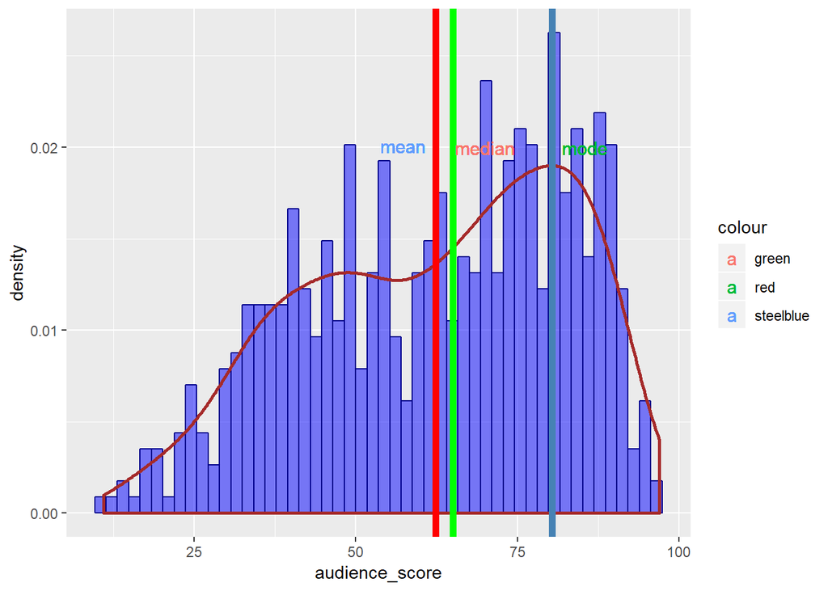

```r
ggplot(df2,aes(x=audience_score,y=..density..))+ geom_histogram(bins=50,fill='blue',color='darkblue',alpha=0.5)+geom_density(size=1,color='brown')+geom_vline(xintercept = mean(df2$audience_score),color='red',size=2)+geom_vline(xintercept = median(df2$audience_score),color='green',size=2)+geom_vline(xintercept = mode,color='steelblue',size=2) +geom_text(aes( x = (mean(df2$audience_score) - 5), y = .020, label = 'mean',
            color = 'steelblue'), size = 4, parse = T) +
  geom_text(aes( x = (median(df2$audience_score) + 5),y = .020,  label = 'median',
            color = 'green'), size = 4, parse = T) +
  geom_text(aes( x = (mode + 5), y = .020, label = 'mode', colour = 'red'),
            size = 4, parse = T)
```

```r
summary(df2$audience_score)
```

```
   Min. 1st Qu.  Median    Mean 3rd Qu.    Max.
  11.00   46.00   65.00   62.36   80.00   97.00
```

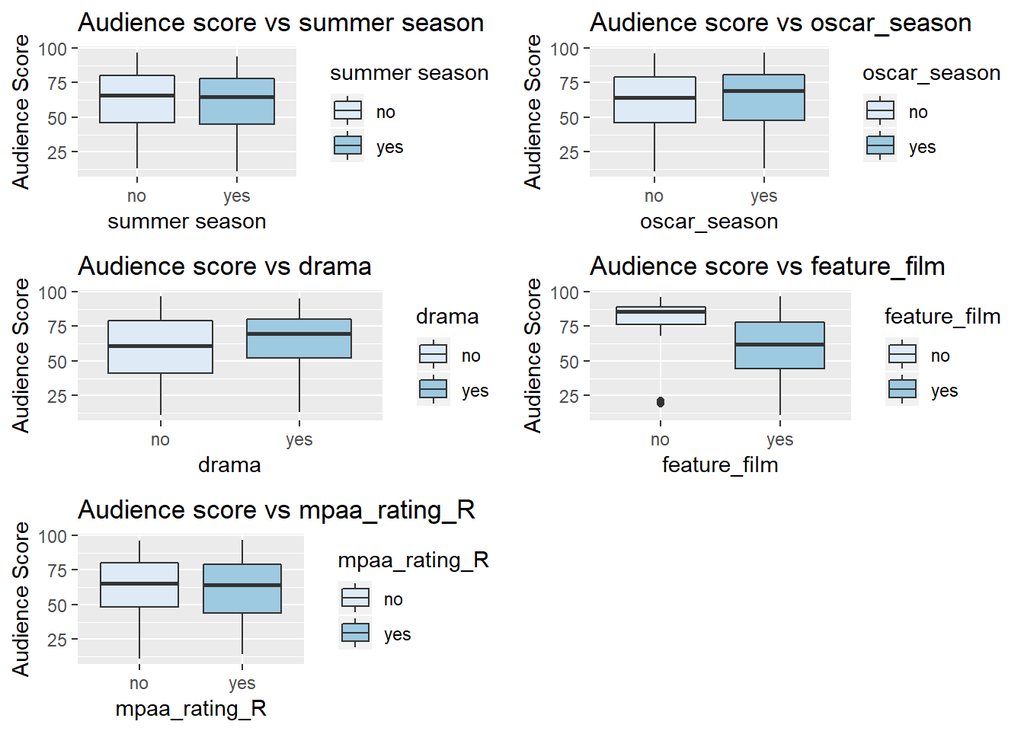

```r
pl1 <- ggplot(df2, aes(x = summer_season, y = audience_score, fill = summer_season)) +
      geom_boxplot() + ggtitle('Audience score vs summer season') + xlab('summer season') +
      ylab('Audience Score') + scale_fill_brewer(name = "summer season")

pl2 <- ggplot(df2, aes(x = oscar_season, y = audience_score, fill = oscar_season)) +
      geom_boxplot() + ggtitle('Audience score vs oscar_season') + xlab('oscar_season') +
      ylab('Audience Score') + scale_fill_brewer(name = "oscar_season")

pl3 <- ggplot(df2, aes(x = drama, y = audience_score, fill = drama)) + geom_boxplot() +
      ggtitle('Audience score vs drama') + xlab('drama') + ylab('Audience Score') +
      scale_fill_brewer(name = "drama")

pl4 <- ggplot(df2, aes(x = feature_film, y = audience_score, fill = feature_film)) +
      geom_boxplot() + ggtitle('Audience score vs feature_film') + xlab('feature_film') +
      ylab('Audience Score') + scale_fill_brewer(name = "feature_film")

pl5 <- ggplot(df2, aes(x = mpaa_rating_R, y = audience_score, fill = mpaa_rating_R)) +
      geom_boxplot() + ggtitle('Audience score vs mpaa_rating_R') + xlab('mpaa_rating_R') +
      ylab('Audience Score') + scale_fill_brewer(name = "mpaa_rating_R")

grid.arrange(pl1,pl2,pl3,pl4,pl5,ncol=2)
```

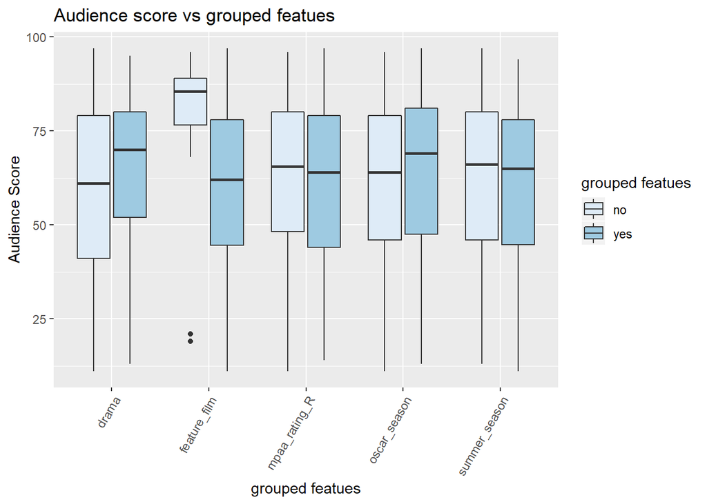

```r
data.grouped <- gather(df2, 'features', 'flag', 2:6)
ggplot(data = data.grouped, aes(x = features, y = audience_score, fill = flag)) + geom_boxplot() +
      ggtitle('Audience score vs grouped featues') + xlab('grouped featues') + ylab('Audience Score') +
      theme(axis.text.x = element_text(angle = 60, hjust = 1)) +
      scale_fill_brewer(name = "grouped featues")
```

The new features do not show much variability in the different features, which leads to the conclusion that none of the above features are valuable towards the prediction of the audience score. The only feature which might be relevant, could be the ‘feature_film’ feature. There seems to be a clear differentiation. But we shouldn’t jump into conclusions right away, therefore we will continue analysing the data.

Let’s take a look at the relation between the response variable and the old features

```r
subset2<-c( 'audience_score', 'feature_film', 'drama', 'runtime', 'mpaa_rating_R', 'thtr_rel_year',
               'oscar_season', 'summer_season', 'imdb_rating', 'imdb_num_votes', 'critics_score',
               'best_pic_nom', 'best_pic_win', 'best_actor_win', 'best_actress_win', 'best_dir_win',
               'top200_box')
```

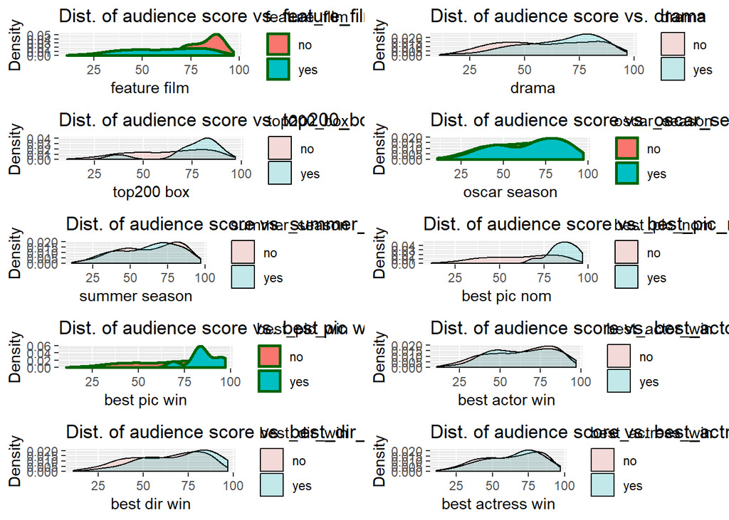

```r
df0 <- df[, subset2]

    # remove NA's
    df0<- na.omit(df0)

    p1 <- ggplot(df0, aes(audience_score, fill = feature_film))
    p1 <- p1 + geom_density(size=1, colour="darkgreen") + labs(title = "Dist. of audience score vs. feature_film") +
               labs(x = "feature film", y = "Density")

    p2 <- ggplot(df0, aes(audience_score, fill = drama))
    p2 <- p2 + geom_density (alpha = 0.2) + labs(title = "Dist. of audience score vs. drama") +
               labs(x = "drama", y = "Density")

    p3 <- ggplot(df0, aes(audience_score, fill = top200_box))
    p3 <- p3 + geom_density (alpha = 0.2) + labs(title = "Dist. of audience score vs. top200_box") +
               labs(x = "top200 box", y = "Density")

    p4 <- ggplot(df0, aes(audience_score, fill = oscar_season))
    p4 <- p4 + geom_density(size=1, colour="darkgreen") + labs(title = "Dist. of audience score vs. oscar_season") +
               labs(x = "oscar season", y = "Density")

    p5 <- ggplot(df0, aes(audience_score, fill = summer_season))
    p5 <- p5 + geom_density (alpha = 0.2) + labs(title = "Dist. of audience score vs. summer_season") +
               labs(x = "summer season", y = "Density")

    p6 <- ggplot(df0, aes(audience_score, fill = best_pic_nom))
    p6  <- p6 + geom_density (alpha = 0.2) + labs(title = "Dist. of audience score vs. best_pic_nom") +
                labs(x = "best pic nom", y = "Density")

    p7 <- ggplot(df0, aes(audience_score, fill = best_pic_win))
    p7 <- p7 + geom_density(size=1, colour="darkgreen") + labs(title = "Dist. of audience score vs. best pic win") +
               labs(x = "best pic win", y = "Density")

    p8 <- ggplot(df0, aes(audience_score, fill = best_actor_win))
    p8 <- p8 + geom_density (alpha = 0.2) + labs(title = "Dist. of audience score vs. best_actor_win") +
               labs(x = "best actor win", y = "Density")

    p9 <- ggplot(df0, aes(audience_score, fill = best_dir_win))
    p9 <- p9 + geom_density (alpha = 0.2) + labs(title = "Dist. of audience score vs. best_dir_win") +
               labs(x = "best dir win", y = "Density")

    p10 <- ggplot(df0, aes(audience_score, fill = best_actress_win))
    p10 <- p10 + geom_density (alpha = 0.2) + labs(title = "Dist. of audience score vs. best_actress_win") +
                 labs(x = "best actress win", y = "Density")

    grid.arrange(p1, p2, p3, p4, p5, p6, p7, p8, p9, p10, ncol = 2)
```

## Part 4: Modeling

```r
subset3 <- c( 'audience_score', 'feature_film', 'drama', 'runtime', 'mpaa_rating_R', 'thtr_rel_year',
               'oscar_season', 'summer_season', 'imdb_rating', 'imdb_num_votes', 'critics_score',
               'best_pic_nom', 'best_pic_win', 'best_actor_win', 'best_actress_win', 'best_dir_win',
               'top200_box')
df3<-df[,subset3]

df3<-na.omit(df3)
str(df3)
```

```
Classes 'tbl_df', 'tbl' and 'data.frame':   650 obs. of  17 variables:
 $ audience_score  : num  73 81 91 76 27 86 76 47 89 66 ...
 $ feature_film    : Factor w/ 2 levels "no","yes": 2 2 2 2 2 1 2 2 1 2 ...
 $ drama           : Factor w/ 2 levels "no","yes": 2 2 1 2 1 1 2 2 1 2 ...
 $ runtime         : num  80 101 84 139 90 78 142 93 88 119 ...
 $ mpaa_rating_R   : Factor w/ 2 levels "no","yes": 2 1 2 1 2 1 1 2 1 1 ...
 $ thtr_rel_year   : num  2013 2001 1996 1993 2004 ...
 $ oscar_season    : Factor w/ 2 levels "no","yes": 1 1 1 2 1 1 1 2 1 1 ...
 $ summer_season   : Factor w/ 2 levels "no","yes": 1 1 2 1 1 1 1 1 1 1 ...
 $ imdb_rating     : num  5.5 7.3 7.6 7.2 5.1 7.8 7.2 5.5 7.5 6.6 ...
 $ imdb_num_votes  : int  899 12285 22381 35096 2386 333 5016 2272 880 12496 ...
 $ critics_score   : num  45 96 91 80 33 91 57 17 90 83 ...
 $ best_pic_nom    : Factor w/ 2 levels "no","yes": 1 1 1 1 1 1 1 1 1 1 ...
 $ best_pic_win    : Factor w/ 2 levels "no","yes": 1 1 1 1 1 1 1 1 1 1 ...
 $ best_actor_win  : Factor w/ 2 levels "no","yes": 1 1 1 2 1 1 1 2 1 1 ...
 $ best_actress_win: Factor w/ 2 levels "no","yes": 1 1 1 1 1 1 1 1 1 1 ...
 $ best_dir_win    : Factor w/ 2 levels "no","yes": 1 1 1 2 1 1 1 1 1 1 ...
 $ top200_box      : Factor w/ 2 levels "no","yes": 1 1 1 1 1 1 1 1 1 1 ...
 - attr(*, "na.action")= 'omit' Named int 334
  ..- attr(*, "names")= chr "334"
```

We will be using the BIC and the Zellner-Siow Cauchy prior for the analysis.

```r
bic_model<-bas.lm(formula=audience_score~.,data=df3,prior = 'BIC',modelprior = uniform())
summary(bic_model)
```

```
                    P(B != 0 | Y)    model 1       model 2       model 3
Intercept              1.00000000     1.0000     1.0000000     1.0000000
feature_filmyes        0.06536947     0.0000     0.0000000     0.0000000
dramayes               0.04319833     0.0000     0.0000000     0.0000000
runtime                0.46971477     1.0000     0.0000000     0.0000000
mpaa_rating_Ryes       0.19984016     0.0000     0.0000000     0.0000000
thtr_rel_year          0.09068970     0.0000     0.0000000     0.0000000
oscar_seasonyes        0.07505684     0.0000     0.0000000     0.0000000
summer_seasonyes       0.08042023     0.0000     0.0000000     0.0000000
imdb_rating            1.00000000     1.0000     1.0000000     1.0000000
imdb_num_votes         0.05773502     0.0000     0.0000000     0.0000000
critics_score          0.88855056     1.0000     1.0000000     1.0000000
best_pic_nomyes        0.13119140     0.0000     0.0000000     0.0000000
best_pic_winyes        0.03984766     0.0000     0.0000000     0.0000000
best_actor_winyes      0.14434896     0.0000     0.0000000     1.0000000
best_actress_winyes    0.14128087     0.0000     0.0000000     0.0000000
best_dir_winyes        0.06693898     0.0000     0.0000000     0.0000000
top200_boxyes          0.04762234     0.0000     0.0000000     0.0000000
BF                             NA     1.0000     0.9968489     0.2543185
PostProbs                      NA     0.1297     0.1293000     0.0330000
R2                             NA     0.7549     0.7525000     0.7539000
dim                            NA     4.0000     3.0000000     4.0000000
logmarg                        NA -3615.2791 -3615.2822108 -3616.6482224
                          model 4       model 5
Intercept               1.0000000     1.0000000
feature_filmyes         0.0000000     0.0000000
dramayes                0.0000000     0.0000000
runtime                 0.0000000     1.0000000
mpaa_rating_Ryes        1.0000000     1.0000000
thtr_rel_year           0.0000000     0.0000000
oscar_seasonyes         0.0000000     0.0000000
summer_seasonyes        0.0000000     0.0000000
imdb_rating             1.0000000     1.0000000
imdb_num_votes          0.0000000     0.0000000
critics_score           1.0000000     1.0000000
best_pic_nomyes         0.0000000     0.0000000
best_pic_winyes         0.0000000     0.0000000
best_actor_winyes       0.0000000     0.0000000
best_actress_winyes     0.0000000     0.0000000
best_dir_winyes         0.0000000     0.0000000
top200_boxyes           0.0000000     0.0000000
BF                      0.2521327     0.2391994
PostProbs               0.0327000     0.0310000
R2                      0.7539000     0.7563000
dim                     4.0000000     5.0000000
logmarg             -3616.6568544 -3616.7095127
```

```r
a<-coefficients(bic_model)
b<-confint(a)
d=cbind(a$postmean,a$postsd,b)
colnames(d)<-c('postmean','poststd','2.5%','97.5%','beta')
d
```

```
                         postmean      poststd          2.5%        97.5%
Intercept            6.234769e+01 3.946018e-01  6.160313e+01 6.312275e+01
feature_filmyes     -1.046908e-01 5.642631e-01 -1.332549e+00 4.190923e-03
dramayes             1.604413e-02 1.939207e-01  0.000000e+00 0.000000e+00
runtime             -2.567772e-02 3.118473e-02 -8.265364e-02 0.000000e+00
mpaa_rating_Ryes    -3.036174e-01 7.032090e-01 -2.111505e+00 0.000000e+00
thtr_rel_year       -4.532635e-03 1.818946e-02 -5.846852e-02 0.000000e+00
oscar_seasonyes     -8.034940e-02 3.773258e-01 -1.000249e+00 1.094264e-03
summer_seasonyes     8.704545e-02 3.831385e-01  0.000000e+00 1.036562e+00
imdb_rating          1.498203e+01 7.310236e-01  1.370625e+01 1.656488e+01
imdb_num_votes       2.080713e-07 1.312970e-06 -4.783915e-07 1.753821e-06
critics_score        6.296648e-02 3.027908e-02  0.000000e+00 1.053408e-01
best_pic_nomyes      5.068035e-01 1.567903e+00  0.000000e+00 4.839939e+00
best_pic_winyes     -8.502836e-03 8.479272e-01  0.000000e+00 0.000000e+00
best_actor_winyes   -2.876695e-01 8.318203e-01 -2.550768e+00 0.000000e+00
best_actress_winyes -3.088382e-01 9.057061e-01 -2.915451e+00 0.000000e+00
best_dir_winyes     -1.195011e-01 6.227133e-01 -1.457696e+00 1.042352e-02
top200_boxyes        8.648185e-02 7.049625e-01  0.000000e+00 0.000000e+00
                             beta
Intercept            6.234769e+01
feature_filmyes     -1.046908e-01
dramayes             1.604413e-02
runtime             -2.567772e-02
mpaa_rating_Ryes    -3.036174e-01
thtr_rel_year       -4.532635e-03
oscar_seasonyes     -8.034940e-02
summer_seasonyes     8.704545e-02
imdb_rating          1.498203e+01
imdb_num_votes       2.080713e-07
critics_score        6.296648e-02
best_pic_nomyes      5.068035e-01
best_pic_winyes     -8.502836e-03
best_actor_winyes   -2.876695e-01
best_actress_winyes -3.088382e-01
best_dir_winyes     -1.195011e-01
top200_boxyes        8.648185e-02
```

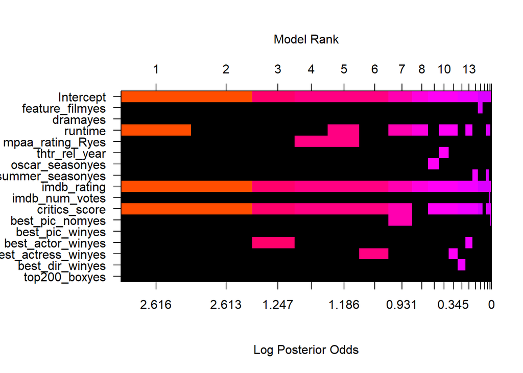

```r
image(bic_model,rotate=F)
```

Lets use the Zellner-Siow Cauchy prior .

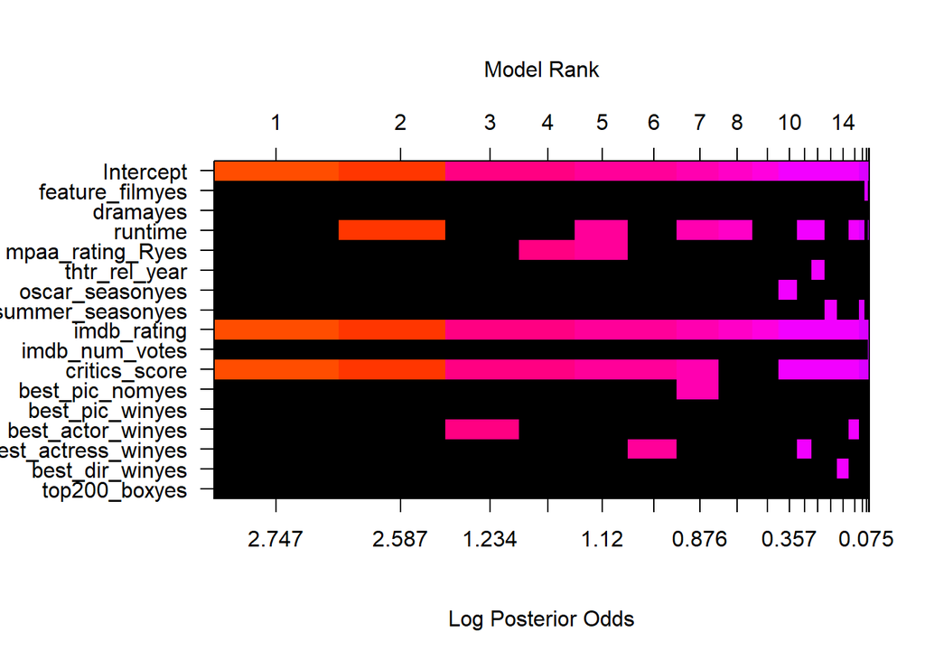

```r
zs_model <-  bas.lm(formula = audience_score~., data = df3,prior="ZS-null",modelprior=uniform(),method = "MCMC", MCMC.iterations = 10^6)

image(zs_model,rotate=F)
```

Based on the two priors used here, we see that the only features which lead us to the top models are runtime, imdb_rating and critics_score.

Hence, we would stick to these features only and find the best model to be used.

```r
subset4<-c('audience_score', 'runtime', 'imdb_rating', 'critics_score')
df4<-df[,subset4]

df4<-na.omit(df4)
```

```r
model_g   = bas.lm(audience_score~., data = df4, prior = "g-prior",  modelprior = uniform())
model_zs  = bas.lm(audience_score~., data = df4, prior = "ZS-null", modelprior = uniform())
model_bic = bas.lm(audience_score~., data = df4, prior = "BIC",    modelprior = uniform())

prob<-cbind(model_g$probne0,model_zs$probne0,model_bic$probne0)
colnames(prob)<-c('g-prior','zs-null prior','bic prior')
rownames(prob)<-c('intercept','runtime','imdb_rating','critics_score')
head(prob)
```

```
                g-prior zs-null prior bic prior
intercept     1.0000000     1.0000000 1.0000000
runtime       0.5040005     0.4724398 0.5101554
imdb_rating   1.0000000     1.0000000 1.0000000
critics_score 0.9015329     0.8854877 0.9050549
```

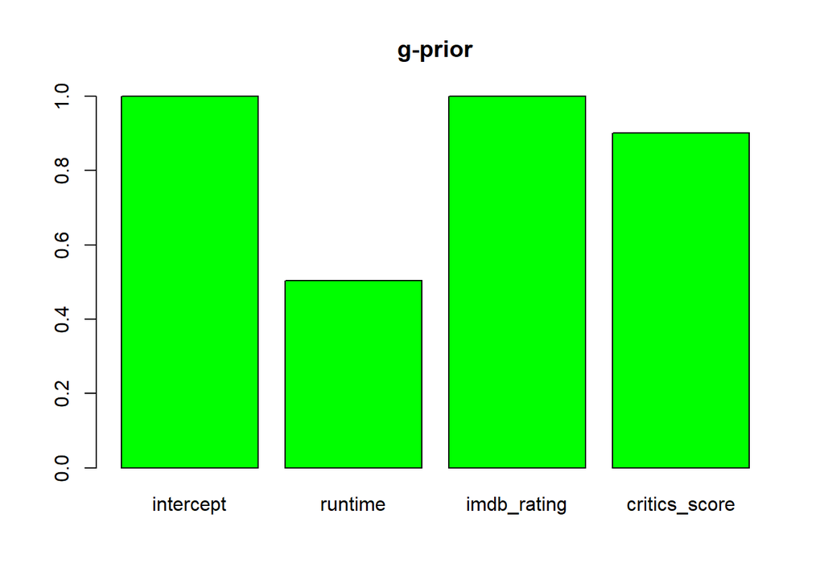

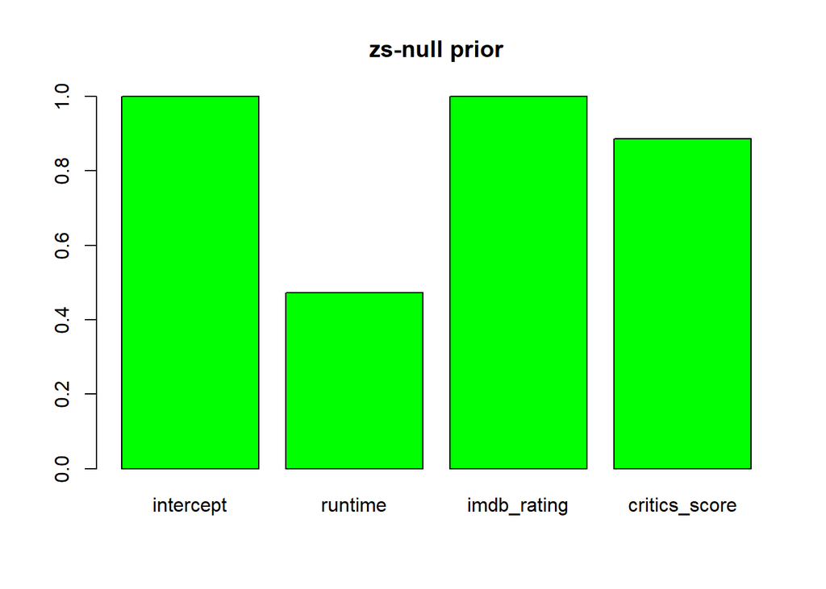

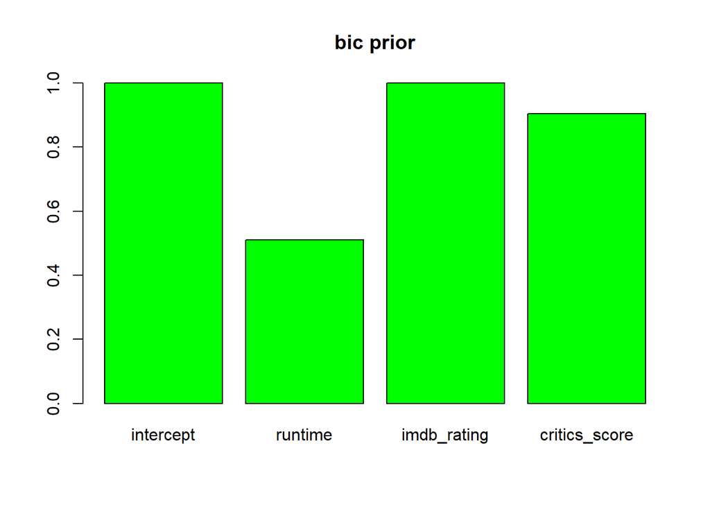

```r
for (i in 1:3){
  barplot(height = prob[,i],main = colnames(prob)[i],ylim=c(0,1),col='green')
}
```

```r
subset5<-c('audience_score', 'imdb_rating', 'critics_score')
df5<-df[,subset5]
df5<-na.omit(df5)
final_model<-bas.lm(formula=audience_score~.,data=df5,prior = 'ZS-null',modelprior =uniform(),method='MCMC',MCMC.iterations = 10^6)
```

```r
BMA=predict(final_model,estimator="BMA")
HPM=predict(final_model,estimator = "HPM")
```

```r
coef(final_model)
```

```
 Marginal Posterior Summaries of Coefficients:

 Using  BMA

 Based on the top  4 models
               post mean  post SD  post p(B != 0)
Intercept      62.3625     0.5612   1.0000
imdb_rating     7.6879     7.7128   0.6667
critics_score   0.1434     0.2089   0.6667
```

## Part 5: Prediction

```r
library(caTools)
set.seed(123)

split<-sample.split(df5$audience_score,SplitRatio = 0.7)
train<-subset(df5,split==T)
test<-subset(df5,split==F)
```

```r
head(test)
```

```
# A tibble: 6 x 3
  audience_score imdb_rating critics_score
           <dbl>       <dbl>         <dbl>
1             76         7.2            80
2             27         5.1            33
3             86         7.8            91
4             47         5.5            17
5             66         6.6            83
6             53         5.9            25
```

```r
final_model2<-bas.lm(formula=audience_score~.,data=train,prior = 'ZS-null',modelprior =uniform(),method='MCMC',MCMC.iterations = 10^6)
predicted<-predict(final_model2,newdata = test,estimator = 'HPM')

head(predicted$fit)
```

```
[1] 73.88171 50.49728 79.35466 42.53662 75.37433 46.51695
```

```r
head(predicted$Ybma)
```

```
         [,1]
[1,] 73.88171
[2,] 50.49728
[3,] 79.35466
[4,] 42.53662
[5,] 75.37433
[6,] 46.51695
```

## Part 6: Conclusion

In this project, we tried to eexclude all the variables which were of least or no use in predicting the audience score. We started of with a lot of variables but it turns out that most of our EDA and our priors for various models suggest that the only variables of value to us for predicting the audience score are the critics score aand imdb rating.

Using these 2 variables, we have tried to predict some part of our data by training a model using the rest of the data.